# Lab2 - Machine Learning

### 1. Linear regression

```python
import numpy as np
import matplotlib.pyplot as plt

%matplotlib inline
```

### Short story

Suppose that someone has given you some points that belongs to the line ( without telling you how they were generated )

$y = b + ax = 3 + 4x$

Goal:

You would like to estimate the parameters $a$ and $b$ that generated the data

```python
X = 2 * np.random.rand(500, 1)
y = 3 + 4 * X + np.random.randn(500, 1)
```

If you want to fix the random generator use numpy >= 1.19.5.

In the following link search for "self.rng" https://github.com/sotirisnik/KLRS/blob/main/buffers.py#L34

You could also try to experiment with the functions

[output not shown]

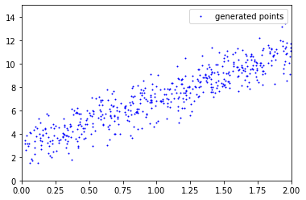

```python
plt.plot( X, y, "b.", markersize='2' )
plt.axis([0, 2, 0, 15])
plt.legend( ['generated points'] )
plt.show()
```

We can apply the normal equation and solve the system directly. We will discuss it later in detail.

```python
A = np.hstack( [ np.ones( (X.shape[0],1) ), X]  )

AT_dot_A = A.T.dot(A)
inv_AT_dot_A = np.linalg.inv( AT_dot_A )

theta = inv_AT_dot_A.dot( A.T ).dot(y)
print( theta )
#A * theta = y
#(A.T * A) * theta = (A.T)*b
#(A.T * A)^{-1} * (A.T * A) * theta  = (A.T * A)^{-1} A.T * b
#theta = (A.T * A)^{-1} A.T * b
```

```
[[2.91242818]
 [4.07038716]]
```

We can make some prediction for points 0 and 2

we would expect

$y = 3 + 4 \thinspace \times \thinspace 0 = 3$

and

$y = 3 + 4 \thinspace \times \thinspace 2 = 11$

```python
X_test = np.array( [ [0],
                    [2] ] )
X_test_b = np.hstack( [ np.ones( ( X_test.shape[0],1) ), X_test ]  )
y_predict = X_test_b.dot(theta)
```

```python
y_predict
```

```
array([[ 2.91242818],
       [11.05320251]])
```

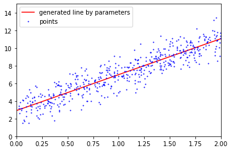

```python
l_x = list( [ i for i in range(25) ] )
plt.plot( l_x, theta[0] + theta[1]*l_x, 'r-' )
plt.plot( X, y, "b.", markersize='2' )
plt.axis([0, 2, 0, 15])
plt.legend( ['generated line by parameters','points'] )
plt.show()
```

## Let's look at it again now by loading a dataset

Suppose you own a restaurant franchise and are considering different cities for opening a new outlet. The chain already has trucks in various cities and you have data for profits and populations from the cities.

You would like to use this data to help you select which city to expand to next. The file lin_data1.txt contains the dataset for our linear regression problem. The first column is the population of a city and the second column is the profit of a food truck in that city. A negative value for profit indicates a loss.

## Load the dataset

```python
import pandas as pd
df = pd.read_csv('data/lin_data1.txt', header=None, sep=',')
```

```python
print( "DataFrame has shape of ", df.shape )
```

```
DataFrame has shape of  (97, 2)
```

View first 5 rows of the dataset, by default pandas head shows the first 5 rows.

```python
df.head(5)
```

|  | 0 | 1 |
| --- | --- | --- |
| 0 | 6.1101 | 17.5920 |
| 1 | 5.5277 | 9.1302 |
| 2 | 8.5186 | 13.6620 |
| 3 | 7.0032 | 11.8540 |
| 4 | 5.8598 | 6.8233 |

### Rename columns

```python
df.columns = [ 'population', 'profit']
```

```python
df.head()
```

|  | population | profit |
| --- | --- | --- |
| 0 | 6.1101 | 17.5920 |
| 1 | 5.5277 | 9.1302 |
| 2 | 8.5186 | 13.6620 |
| 3 | 7.0032 | 11.8540 |
| 4 | 5.8598 | 6.8233 |

```python
df.to_numpy()[:5]
```

```
array([[ 6.1101, 17.592 ],
       [ 5.5277,  9.1302],
       [ 8.5186, 13.662 ],
       [ 7.0032, 11.854 ],
       [ 5.8598,  6.8233]])
```

```python
X = df[ ["population"] ].to_numpy()
y = df[ ["profit"] ].to_numpy()#we could just use "profit" instead of a list, but the shape would be (97,)
```

```python
print( X.shape, y.shape )
```

```
(97, 1) (97, 1)
```

## Visualize the dataset

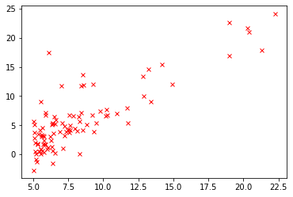

```python
plt.plot( X, y, 'rx', markersize=5 )
plt.show()
```

## Gradient Descent

We have to fit our parameters theta to our dataset

The objective of linear regression is to minimize the cost function, where:

m: is the number of training examples

$\theta$: are our parameteres we want to fit in the model

$x^{(i)}$: is the i-training example

$x^{(i)}_{j}$: is the i-training example and j-th feature

$y^{(i)}$: is desired output

$$ J(θ) = \frac{1}{2 m} \sum_{i=1}^{m} ( h_{\theta}( x^{(i)} ) - y^{(i)} )^{2} $$

and the hypothesis $h_{\theta}$

$$h_{\theta}(x) = \theta^{T}x = \theta_{0} + \theta_{1}x1$$

and the parameters $\theta_{j}$ have to be updated simultraneously for all j.

$$\theta_{j} = \theta_{j} - a \frac{1}{m} \sum_{i=1}^{m} ( h_{\theta}( x^{(i)} ) - y^{(i)} ) x^{(i)}_{j}$$

In this example $j=0 \ldots 1$.

Hint: Calculate and store the gradient for each component j, then update each component in $\theta$.

To accomodate the parameter $\theta_{0}$ we have to add a column of 1s to our training set

```python
m = X.shape[0]#total number of examples

X = np.hstack( [ np.ones( (m,1) ), X ]  )#add a column of 1s at the beginning
theta = np.zeros( (2,1) )#parameters theta are assigned to 0
iterations = 1500
alpha = 0.01#the learning rate
```

```python
X.shape#y_train.shape
```

```
(97, 2)
```

```python
def computeCost( X, y, theta ):
    #Input: data points: X, labels: y
    #Return: #Compute the cost for Linear Regression

    m = X.shape[0]#number of training examples

    # You need to return the following variables correctly
    J = 0

    # ====================== YOUR CODE HERE ======================
    # Instructions: Compute the cost of a particular choice of theta
    #               You should set J to the cost.

    J = (1 / (2.0*m) ) * np.sum( ( ( np.dot(X,theta)-y)**2 ) )

    return J
```

```python
def gradientDescent(X, y, theta, alpha, num_iters):
    #GRADIENTDESCENT Performs gradient descent to learn theta
    #   theta = GRADIENTDESENT(X, y, theta, alpha, num_iters) updates theta by
    #   taking num_iters gradient steps with learning rate alpha

    m = X.shape[0]#number of training examples
    J_history = np.zeros( (num_iters,1) )

    for which_iter in range(num_iters):

        # ====================== YOUR CODE HERE ======================
        # Instructions: Perform a single gradient step on the parameter vector
        #               theta.
        #
        # Hint: While debugging, it can be useful to print out the values
        #       of the cost function (computeCost) and gradient here.
        #

        """
        ###begin solution1
        cost = computeCost( X, y, theta )

        new_theta = np.zeros_like( theta )

        for j in range( len(new_theta) ):
            Suma = 0
            for i in range( m ):
                Suma += ( np.dot(theta.T,X[i,:]) - y[i] ) * X[i][j]
            new_theta[j] = theta[j] - alpha * Suma / ( m + 0.0 )

        theta = new_theta

        J_history[which_iter] = cost
        continue
        ###end of solution1
        """

        #calculate error
        error = ( np.dot(X,theta) ) - y

        #calculate theta parameters
        temp0 = theta[0] - ( alpha / m ) * np.sum( error * X[:,0].reshape( (-1,1) ) )
        temp1 = theta[1] - ( alpha / m ) * np.sum( error * X[:,1].reshape( (-1,1) ) )

        #update theta with the new values
        theta = np.array( [temp0, temp1] )

        #print( theta )
        #Save the cost J in every iteration
        J_history[which_iter] = computeCost(X, y, theta)

    return ( J_history, theta )
```

Test the compute function, before starting training. Tt should be near 32.072

```python
computeCost( X, y, theta )
```

```
32.072733877455676
```

J_history contains the error per iteration new_theta contains the final parameters, they should be $ -3.63029144$ and $1.16636235 $

```python
J_history, new_theta = gradientDescent( X, y, theta, alpha, iterations )
```

```python
new_theta
```

```
array([[-3.63029144],
       [ 1.16636235]])
```

And the cost after training should be around 4.48

```python
computeCost( X, y, new_theta )
```

```
4.483388256587725
```

Finally we can plot the Cost function per iteration. The error should be decreasing as long as the number of iterations increases.

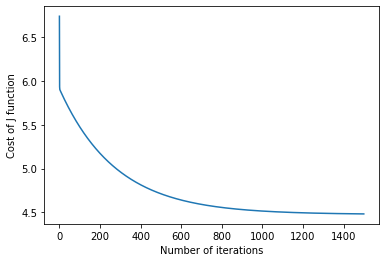

```python
plt.plot( np.arange(J_history.shape[0]), J_history )
plt.xlabel( 'Number of iterations' )
plt.ylabel( 'Cost of J function' )
plt.show()
```

## Visualize line

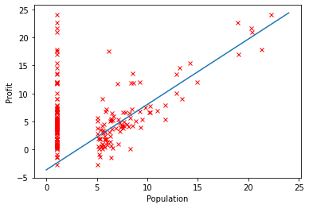

```python
plt.plot( X, y, 'rx', markersize=5 )
l_x = list( [ i for i in range(25) ] )
plt.plot( l_x, new_theta[0] + new_theta[1]*l_x )
plt.xlabel( 'Population' )
plt.ylabel( 'Profit' )
plt.show()
```

## Normal equation

Let's find a closed form for theta. The cost function we want to minimize is

$$ J(θ) = \frac{1}{2 m} \sum_{i=1}^{m} ( h_{\theta}( x^{i} ) - y^{i} )^{2} $$

and the hypothesis $h_{\theta}$ is

$$h_{\theta}(x) = \theta^{T}x = \theta_{0} + \theta_{1}x1$$

So ( $\frac{1}{2m}$ can be ommited )

$$ J(θ) = \frac{1}{2 m} ( X \theta - y )^{T} (X \theta - y) $$$$ J(θ) = ( X \theta - y )^{T} (X \theta - y) $$$$ J(θ) = ( (X \theta)^{T} - y^{T} ) (X \theta - y) $$$$ J(θ) = (X \theta)^{T} X \theta - (X \theta)^{T}y - y^{T} (X \theta) + y^{T}y $$

( recall that that the order of the factors reverses $(AB)^{T} = B^T A^{T}$ )

$$ J(θ) = \theta^{T}X^{T} X \theta - (X \theta)^{T}y - (X \theta)^{T}y + y^{T}y $$$$ J(θ) = \theta^{T}X^{T} X \theta - 2 (X \theta)^{T}y + y^{T}y $$

In order to find the minimum we will derive by $\theta$ and compare to 0

For the derivative we also need 3 rules to keep in mind:

- Rule1: $\nabla_{x}( x^{T} A^{T} A x ) = 2 A^T A x$
- Rule2: $\nabla_{x} ( x^{T} A^{T} b ) = A^{T} b$
- Rule3: $\nabla_{x} ( b^{T} A x ) = A^{T} b$

$$ \nabla_{\theta} J = 2 X^{T} X \theta - 2 X^{T} y $$$$ \nabla_{\theta} J = 0 $$$$ 2 X^{T} X \theta - 2 X^{T} y = 0 $$$$ 2 X^{T} X \theta = 2 X^{T} y $$$$ X^{T} X \theta = X^{T} y $$

finally multiply $( X^{T} X )^{-1}$

$$ \theta = ( X^{T} X )^{-1} X^{T} y $$

```python
lamda = 0
N, D = X.shape
t = y
w = np.linalg.solve( X.T.dot(X) + lamda*np.eye(D), X.T.dot(t) )
```

```python
print( 'From linear regression' )
print( new_theta )

print( '' )

print( 'From normal equation' )
print( w )
```

```
From linear regression
[[-3.63029144]
 [ 1.16636235]]

From normal equation
[[-3.89578088]
 [ 1.19303364]]
```

## Logistic Regression

Suppose that you are the administrator of a university department and you want to determine each applicant’s chance of admission based on their results on two exams. You have historical data from previous applicants that you can use as a training set for logistic regression. For each training example, you have the **applicant’s scores on two exams** and the **admissions decision**. Your task is to build a classification model that estimates an applicant’s probability of admission based the scores from those two exams.

```python
df = pd.read_csv('data/log_data1.txt', header=None, sep=',', names=['test1','test2','admission'] )
```

```python
df.head(5)
```

|  | test1 | test2 | admission |
| --- | --- | --- | --- |
| 0 | 34.623660 | 78.024693 | 0 |
| 1 | 30.286711 | 43.894998 | 0 |
| 2 | 35.847409 | 72.902198 | 0 |
| 3 | 60.182599 | 86.308552 | 1 |
| 4 | 79.032736 | 75.344376 | 1 |

```python
X = df[ ["test1","test2"] ].to_numpy()
y = df[ ["admission"] ].to_numpy()
```

Again we add a column of 1s for $theta0$

```python
X = np.hstack( [ np.ones( ( X.shape[0],1) ), X ]  )
```

```python
X[:5]
```

```
array([[ 1.        , 34.62365962, 78.02469282],
       [ 1.        , 30.28671077, 43.89499752],
       [ 1.        , 35.84740877, 72.90219803],
       [ 1.        , 60.18259939, 86.3085521 ],
       [ 1.        , 79.03273605, 75.34437644]])
```

Sklearn provides a useful function to split in training and test dataset

test_size=0.3 means that 70% of the data will be given on the training set and 30% on the testing set.

If we set the random state to a constant it will always give the same result. ( e.x. to reproduce results )

```python
from sklearn.model_selection import train_test_split
X_train, X_test, y_train, y_test = train_test_split( X, y, test_size=0.3, random_state=42)
```

```python
print( X_train.shape )
print( y_train.shape )
print( X_test.shape )
print( y_test.shape )
```

```
(70, 3)
(70, 1)
(30, 3)
(30, 1)
```

## Preprocessing

We are going to apply mean normalization both on training and testing set. Notice that we omit the calcuation of the theam mean(mu) and std(stud) for the first column which contains the columns of 1s.

Hint: It is not mandatory to the add the column of 1s to the training/test data. We could add the column of 1s tentatively during the predict/training calls.

```python
m, n = X.shape
mu = np.zeros( (X_train.shape[1], 1) )
stdu = np.zeros( (X_train.shape[1], 1) )
for j in range(1,n):
    mu[j] = X[:,j].mean()
    stdu[j] = X[:,j].std()

stdu[0] = 1#because otherwise it will divide by 0 later on standarization
```

```python
mu
```

```
array([[ 0.        ],
       [65.64427406],
       [66.22199809]])
```

```python
stdu
```

```
array([[ 1.        ],
       [19.36068671],
       [18.48963567]])
```

## Standardize training set

```python
for j in range(1,n):
    X_train[:, j] = (X_train[:, j] - mu[j] ) / stdu[j]
```

## Standardize test set

```python
for j in range(1,n):
    X_test[:, j] = (X_test[:, j] - mu[j] ) / stdu[j]
```

```python
pd.DataFrame( X_train ).head()
```

|  | 0 | 1 | 2 |
| --- | --- | --- | --- |
| 0 | 1.0 | 0.483939 | -1.926416 |
| 1 | 1.0 | 1.659410 | 1.109044 |
| 2 | 1.0 | 0.145875 | 1.047739 |
| 3 | 1.0 | -0.197001 | -0.863505 |
| 4 | 1.0 | 0.457030 | 1.007220 |

```python
pd.DataFrame( X_test ).head()
```

|  | 0 | 1 | 2 |
| --- | --- | --- | --- |
| 0 | 1.0 | -0.434156 | -0.362782 |
| 1 | 1.0 | -1.607369 | -0.315077 |
| 2 | 1.0 | -1.700427 | -1.239334 |
| 3 | 1.0 | -0.176729 | -0.765889 |
| 4 | 1.0 | -0.753926 | -1.103283 |

#### Sigmoid function

$$\sigma(a) = \frac{1}{1 + e^{-a}}$$

```python
def sigmoid(z):
    return 1.0 / (1.0 + np.exp(-z))
```

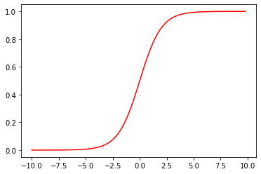

```python
x = np.arange(-10., 10., 0.2)
plt.plot(x, sigmoid(x),'r')
plt.show()
```

Bishop - Pattern Recognition and Machine Learning, page 205

$$ p\big(c=1 \mid \mathbf{x}\big) = \sigma \big(b + \mathbf{x}^{\top} \mathbf{w}\big) $$$$ h_{\theta}(x) = \sigma \big(b + \mathbf{x}^{\top} \mathbf{w}\big) $$$$ J(\theta) = \sum_{n=1}^{m} \big [ y^{ (i) } \ln h_{\theta}( x^{(i)} ) +(1−y^{(i)})\ln(1− h_{\theta}( x^{(i)} ) \thinspace )\big ]- \frac{\lambda}{2} \lVert \mathbf{w} \rVert^2$$

And the partial derivatives for all parameter $\theta_{j}$

$$ \frac{ \partial J(\theta) }{ \partial \theta_{j} } = \sum_{i=1}^{m} [ ( h_{ \theta} ( x^{(i)} ) - y^{(i)}) x^{i}_{j} ] - \lambda \mathbf{w} $$

```python
def ComputeCostGrad( X, y, theta, _lambda ):

    h = sigmoid( X.dot(theta) )#hypothesis h_theta

    #calc cost function
    reg = (_lambda / (2.0 ) ) * np.sum(theta**2)#reguralization
    cur_j = (y.T.dot(np.log(h)) + (1 - y).T.dot(np.log(1 - h))) - reg

    #calculate gradient
    reg = _lambda * theta# /(m+0.0)
    grad = ( X.T.dot( y - h ) ) - reg

    return cur_j, grad


def ComputeLogisticRegression( X, y, X_val, y_val, _lambda=0.0, tot_iter=2000, alpha=0.01 ):

    theta = np.zeros(X.shape[1]).reshape( (-1,1) )

    m, n = X.shape

    J_train = []
    J_test = []

    for i in range( tot_iter ):

        train_error, train_grad = ComputeCostGrad( X, y, theta, _lambda )
        test_error, _ = ComputeCostGrad( X_val, y_val, theta, _lambda )

        #update parameters by subtracting gradient values
        theta += alpha * train_grad

        #print( train_error )
        #store current cost
        J_train.append( train_error[0] )
        J_test.append( test_error[0] )

    return J_train, J_test, theta
```

## Predict

```python
def predict(theta, X):
    #PREDICT Predict whether the label is 0 or 1 using learned logistic
    #regression parameters theta
    #   p = PREDICT(theta, X) computes the predictions for X using a
    #   threshold at 0.5 (i.e., if sigmoid( X * theta ) >= 0.5, predict 1)

    m = X.shape[0]

    #You need to return the following variables correctly
    p = np.zeros( (m,1) );
    p = sigmoid( np.dot(X,theta) )
    prob = p
    p = p > 0.5 - 1e-6

    return p, prob
```

```python
J_train, J_test, theta = ComputeLogisticRegression( X_train, y_train, X_test, y_test, _lambda=0.0 )
```

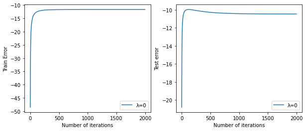

```
Accuracy of training set 0.9142857142857143
Accuracy of testing set 0.8333333333333334
```

```python
plt.figure( figsize=(10,4) )
plt.subplot( 1, 2, 1 )
plt.plot( np.arange( len(J_train) ), J_train, label='λ=0' )
plt.xlabel( 'Number of iterations' )
plt.ylabel( 'Train Error' )
plt.legend()
plt.subplot( 1,2,2)
plt.plot( np.arange( len(J_test) ), J_test, label='λ=0' )
plt.xlabel( 'Number of iterations' )
plt.ylabel( 'Test error' )
plt.legend()
plt.show()
p_train, prob_train = predict( theta, X_train )
p_test, prob_test = predict( theta, X_test )
print( 'Accuracy of training set', np.mean( p_train.astype('int') == y_train ) )
print( 'Accuracy of testing set', np.mean( p_test.astype('int') == y_test ) )
```

```python
p_train, prob_train = predict( theta, X_train )
```

```python
p_train[:5]
```

```
array([[False],
       [ True],
       [ True],
       [False],
       [ True]])
```

```python
print( prob_train[:5] )
```

```
[[0.01959864]
 [0.99999839]
 [0.99752267]
 [0.04742289]
 [0.99932636]]
```

## Accuracy

```python
p_test, prob_test = predict( theta, X_test )
```

```python
print( 'Accuracy of training set', np.mean( p_train.astype('int') == y_train ) )
print( 'Accuracy of testing set', np.mean( p_test.astype('int') == y_test ) )
```

```
Accuracy of training set 0.9142857142857143
Accuracy of testing set 0.8333333333333334
```

```python
theta.shape
np.array( [1,1,1] ).shape
```

```
(3,)
```

```python
predict( theta, ( np.array( [1, 45, 85] ).reshape(1,-1) - mu.T ) / stdu.T )
```

```
(array([[ True]]), array([[0.54572023]]))
```

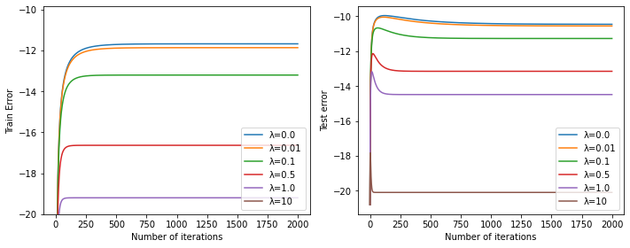

```python
train_stats, test_stats = [], []
for value in [ 0.0, 0.01 , 0.1, 0.5, 1.0, 10 ]:
    J_train, J_test, theta = ComputeLogisticRegression( X_train, y_train, X_test, y_test, _lambda=value )
    train_stats.append( {'history' : J_train, 'lambda': value} )
    test_stats.append( {'history' : J_test, 'lambda': value} )

plt.figure( figsize=(10,4) )
plt.subplot( 1, 2, 1 )
for i in range( len(train_stats) ):
    plt.plot( np.arange( len(train_stats[i]['history']) ), train_stats[i]['history'], label='λ=' + str( train_stats[i]['lambda'] ) )
plt.xlabel( 'Number of iterations' )
plt.ylabel( 'Train Error' )
plt.ylim( [-20,None] )
plt.legend()
plt.subplot( 1,2,2)
for i in range( len(train_stats) ):
    plt.plot( np.arange( len(test_stats[i]['history']) ), test_stats[i]['history'], label='λ='+ str( test_stats[i]['lambda'] ) )
plt.xlabel( 'Number of iterations' )
plt.ylabel( 'Test error' )
plt.legend()
plt.tight_layout()
plt.show()
```

## Logistic Regression from sklearn

The scikit-learn project started as scikits.learn, a Google Summer of Code project by David Cournapeau. Its name stems from the notion that it is a "SciKit" (SciPy Toolkit), a separately-developed and distributed third-party extension to SciPy.

Scikit-learn (formerly scikits.learn) is a free software machine learning library for the Python programming language. It features various classification, regression and clustering algorithms including support vector machines, random forests, gradient boosting, k-means and DBSCAN, and is designed to interoperate with the Python numerical and scientific libraries NumPy and SciPy.

```python
from sklearn.linear_model import LogisticRegression
```

```python
from sklearn.linear_model import LogisticRegression
clf = LogisticRegression(random_state=0, solver='lbfgs',multi_class='multinomial').fit(X_train, y_train.ravel() )
```

```python
clf.score(X_train,y_train)
```

```
0.9142857142857143
```

```python
clf.predict_proba( X_train )[:5]
```

```
array([[9.05481009e-01, 9.45189914e-02],
       [4.35385152e-04, 9.99564615e-01],
       [3.08707203e-02, 9.69129280e-01],
       [8.52983507e-01, 1.47016493e-01],
       [1.46219755e-02, 9.85378024e-01]])
```

```python
clf.score(X_test,y_test)
```

```
0.8333333333333334
```

We got the same accuracy with lambda=0.